# Problema 1 - Checkpoint 1 - Nossa pergunta

```r
library(ggplot2)
library(dplyr)
library(tidyr)
library(readr)
theme_set(theme_minimal())
```

## Descrição dos dados

O conjunto de dados a ser estudado aqui, reune informações sobre a avaliação dada no IBDM de algumas séries populares na atualidade. Os dados foram coletados através de métodos descritos [aqui](https://github.com/nazareno/imdb-series).

A base da dados contêm informações de cada episódio da série, sua avaliação no IBDM, o número de votos recebidos por cada episódio e as proporções de votos de 1 a 10 para cada episódio.

Nesta análise serão estudadas as seguintes séries, que foram escolhidas aleatóriamente do conjunto de dados disponível:

- Agents of S.H.I.E.L.D.
- House of Cards
- Orphan Black
- The 100
- The Blacklist
- Vikings

```r
series <- read_csv("series_from_imdb.csv") %>%
  filter(series_name %in% c("Agents of S.H.I.E.L.D.", "House of Cards", "Orphan Black", "The 100", "The Blacklist", "Vikings"))
```

## Melhor avaliada

Tentaremos analizar o quão bem avaliada é uma série, a príncípio vejamos como é a classificação das séries escolhidas de acordo com os votos dos usuários no IMDB.

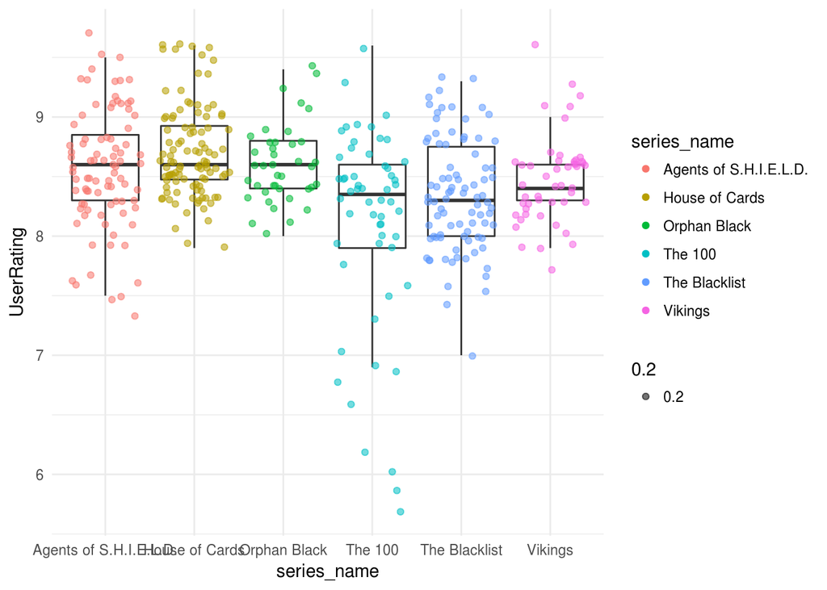

```r
ggplot(data = series, aes(x = series_name, y = UserRating)) +
  geom_boxplot(outlier.shape = NA) +
  geom_jitter(aes(color = series_name, alpha = 0.2))
```

Como podemos observar no boxplot acima as avalições das séries se concentram, em sua maioria, em torno de 7.5 e 9.5, com medianas sempre entre 8 e 9.

De acordo com o gráfico **Agents of S.H.I.E.L.D., House of Cards e Orphan Black** então empatadas como as séries de melhor avaliação se observarmos a mediana dos votos. As três com 8.6 de mediana.

As demais séries estão relativamente próximas das que estão em primeiro, a que mais se distancia é *The Blacklist* com uma diferença de apenas 0.3, ou seja, uma mediana de 8.3.

Nota-se ainda o quão dispersos estão os dados, com destaque especial para *The 100* que possui algumas observações bastante dispersas, chegando até a avaliações menores que 6 em alguns episódios.

Vejamos agora uma observação ainda mais sumarizada das variáveis através da média e da mediana dos votos no IMDB.

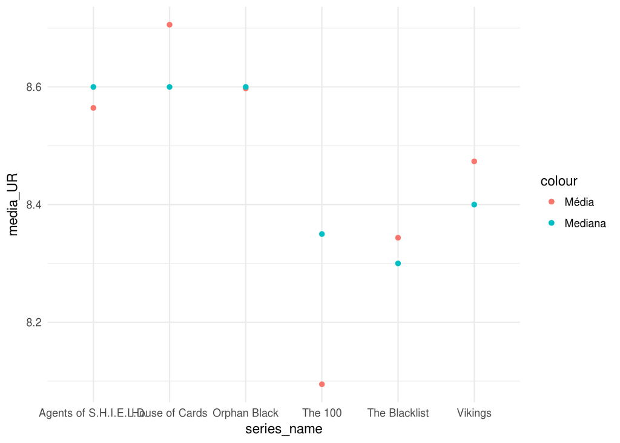

```r
sum_series <- series %>%
  group_by(series_name) %>%
  summarise(total_eps = n(),
            media_UR = mean(UserRating),
            mediana_UR = median(UserRating)
            )

ggplot(data = sum_series, aes(x = series_name)) +
  geom_point(aes(x = series_name, y = media_UR, color = "Média")) +
  geom_point(aes(x = series_name, y = mediana_UR, color = "Mediana"))
```

Observa-se que os valores de média e mediana são, em geral, próximos, significando que ambos são representativos para os dados.

### Uma nova métrica

Tentaremos usar uma métrica diferente para perceber se uma série é boa ou não.  
Veremos a proporção de pessoas que amou a série, ou seja, que deu 10 na avaliação dos episódios

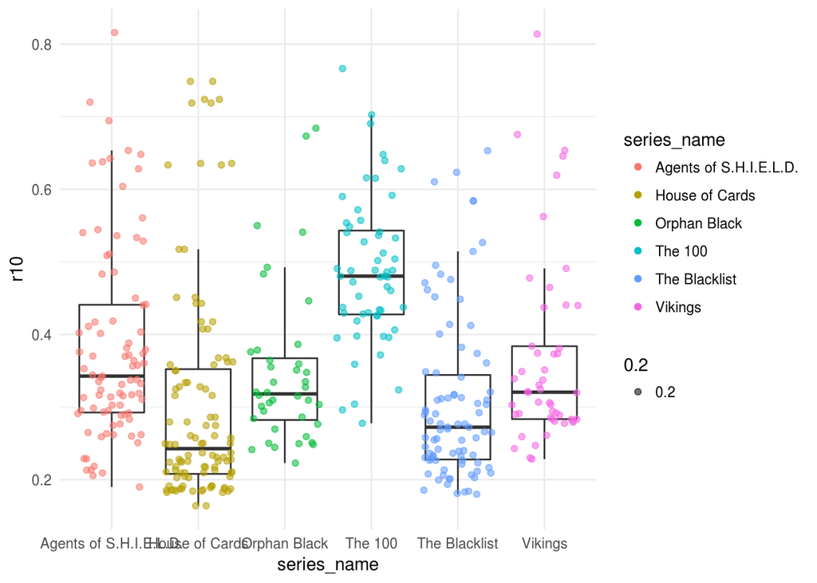

```r
ggplot(data = series, aes(x = series_name, y = r10)) +
  geom_boxplot(outlier.shape = NA) +
  geom_jitter(aes(color = series_name, alpha = .2))
```

Através desse parâmero, curiosamente, os dados se invertem, **The 100** que na avalição anterior era a de menor média e a de 2ª menor mediana é a série mais recebe nota 10 dentre as observadas.  
Por outro lado, **House of Cards** que figurava entre as melhores é a que menos tem avaliações com nota 10.

## Regularidade dos episódios

Para avaliar a regularidade dos episódios, traçaremos a linha do tempo dos episódios de cada série.

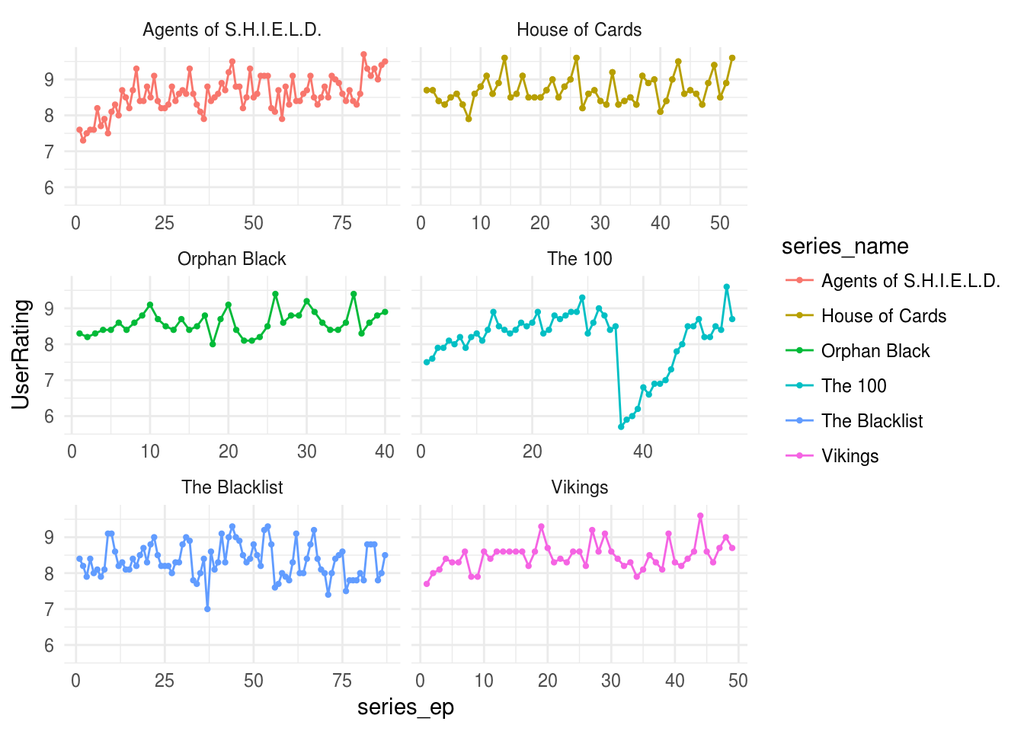

```r
ggplot(data = series, aes(x = series_ep, y = UserRating, color = series_name)) +
  geom_line() +
  geom_point(size = 0.8) +
  facet_wrap(~series_name, scales = 'free_x', ncol = 2)
```

Essa visualização nos permite verificar com precisão o desempenho de cade episódio de cada série, no entanto não nos ajuda muito a compreender a tendência dos dados, para tal, usaremos a visualização a seguir.

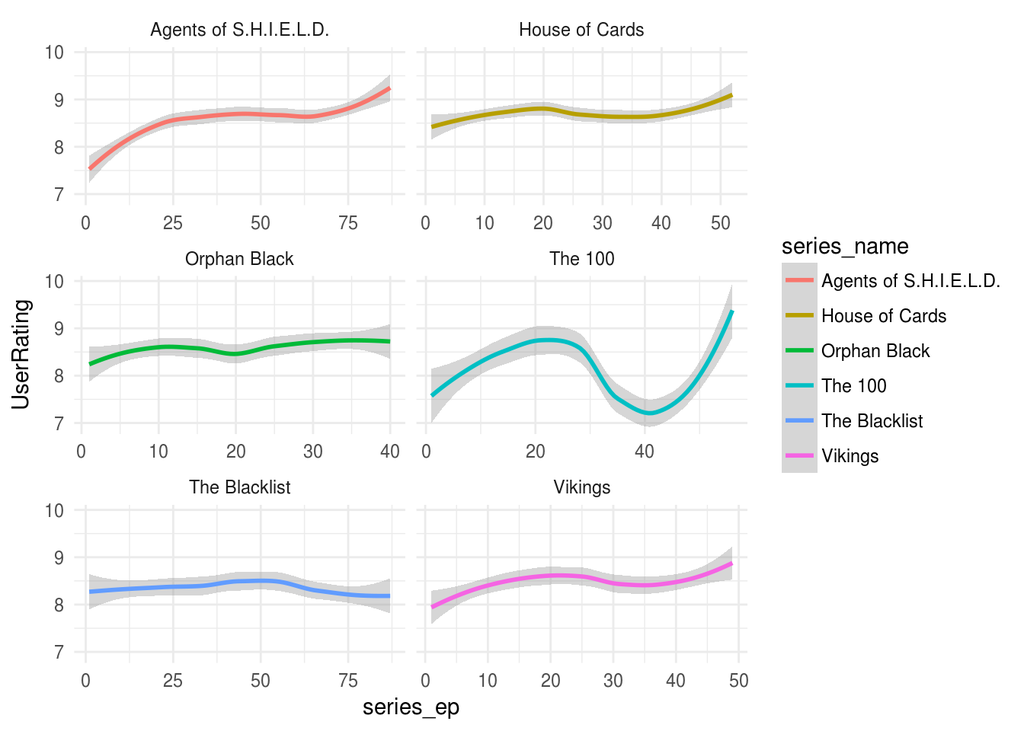

```r
ggplot(data = series, aes(y = UserRating , x = series_ep, color = series_name)) +
  geom_smooth() +
  facet_wrap(~series_name, scales = 'free_x', ncol = 2)
```

Agora é possível observar o comportamento geral de cada série, note que esta visualizão é uma aproximação da anterior. Vemos que em geral não existem variações bruscas na qualidade dos episódios das séries, exceto por *The 100* que apresentou uma sequência de valores considerávelmente baixos.